# Comparing `rtrees` to my models

Katherine Goode

September 17, 2020

This journal contains the results from 100 new random forests to the bullet training data observations where `flag == FALSE`.

```r
library(cowplot)
library(dplyr)
library(ggplot2)
library(purrr)
library(randomForest)
library(tidyr)
```

# Data

Load the prepared training data which only has observations with `flag == FALSE` (prepared in the LIME diagnostics paper repository):

```r
bullet_train <- read.csv("../../../diagnostics-paper/data/bullet-train.csv")
```

Load the random forest `rtrees` from the `bulletxtrctr` package and the random forest model I recently fit using the `bullet_train` data in the paper:

```r
rtrees <- bulletxtrctr::rtrees
paper_rf <- readRDS("../../../diagnostics-paper/data/bullet-rf.rds")
```

Extract the features used to fit `rtrees`:

```r
bullet_features <- rownames(bulletxtrctr::rtrees$importance)
bullet_features
```

```
## [1] "ccf"        "rough_cor"  "D"          "sd_D"       "matches"
## [6] "mismatches" "cms"        "non_cms"    "sum_peaks"
```

# `rtrees` versus paper model

The code below was used to fit the random forest in the paper but is not run here:

```r
set.seed(20160104)
bullet_rf <-
  randomForest(
    y = factor(bullet_train$samesource),
    x = bullet_train %>% select(all_of(bullet_features)),
    ntree = bulletxtrctr::rtrees$ntree,
    mtry = bulletxtrctr::rtrees$mtry
  )
```

Confusion matrices from the two models:

```r
rtrees$confusion
```

```
##       FALSE TRUE class.error
## FALSE 81799   21 0.000256661
## TRUE    363  845 0.300496689
```

```r
paper_rf$confusion
```

```
##       FALSE TRUE  class.error
## FALSE 82987   29 0.0003493302
## TRUE    363  876 0.2929782082
```

Variable importance values:

```r
vi = data.frame(
  features = rownames(rtrees$importance),
  rtrees = rtrees$importance[, 1],
  paper = paper_rf$importance[, 1]
)
```

# New Random Forests

Randomly select 100 seeds (using a random seed):

```r
set.seed(20200917)
seeds = sample(x = 10000000:100000000, size = 100, replace = FALSE)
seeds
```

```
##   [1] 27449599 81017245 24538320 36475265 23315815 92542218 13850696 73480935
##   [9] 16032616 77075055 14962583 81096517 22226686 48834626 76160652 58096585
##  [17] 98014825 69100764 67754872 42806813 39170240 44867073 40746233 37446369
##  [25] 79777926 28680213 61343357 22148932 38789752 32436863 36933855 90548583
##  [33] 99006745 37602222 69641254 48738383 57560591 67812530 89095659 90463622
##  [41] 84124659 64775025 56964614 56493662 93418818 41837966 10475206 54640393
##  [49] 95299400 43474972 50772416 64775325 41405785 19197603 94902116 46247672
##  [57] 50861599 42881646 82233165 98246761 25824185 79054030 96833729 94803981
##  [65] 98452591 34103737 86408897 17410890 90024367 67811357 10161301 19911074
##  [73] 13272999 72493619 23442339 58720113 18581245 18826523 49967575 10471102
##  [81] 12436840 59859168 98793526 72267464 54581063 79601150 66567971 81728121
##  [89] 78097707 43686139 87361988 53524379 89635808 45292048 48764395 71907301
##  [97] 25785070 32095388 32432416 63518177
```

Function for fitting random forests to mimic rtrees with different seeds:

```r
fit_rf <- function(seed) {
  set.seed(seed)
  bullet_rf <-
    randomForest(
      y = factor(bullet_train$samesource),
      x = bullet_train %>% select(all_of(bullet_features)),
      ntree = bulletxtrctr::rtrees$ntree,
      mtry = bulletxtrctr::rtrees$mtry
    )
}
```

Fit 100 new random forests and save or load:

```r
# Fit (and save) or load random forests
bullet_rfs_file = "../../../data/bullet_rfs.rds"
if (!file.exists(bullet_rfs_file)) {
  bullet_rfs = map(.x = seeds, .f = fit_rf)
  saveRDS(object = bullet_rfs, file = bullet_rfs_file)
} else {
  bullet_rfs = readRDS(bullet_rfs_file)
}
```

Function for extracting the confusion matrices from the model and put in a nice data frame:

```r
extract_confus <- function(model) {
  data.frame(model$confusion) %>%
  rename("FALSE" = "FALSE.", "TRUE" = "TRUE.", "class_error" = "class.error") %>%
  mutate(observed = rownames(model$confusion)) %>%
  pivot_wider(names_from = observed, values_from = everything())
}
```

Function for extracting the importance values, computing the rank of the features based on importance, and putting in a data frame:

```r
extract_importance <- function(model) {
  data.frame(model$importance) %>%
    mutate(features = rownames(model$importance)) %>%
    arrange(desc(MeanDecreaseGini)) %>%
    mutate(rank = 1:n()) %>%
    rename("importance" = "MeanDecreaseGini") %>%
    select(features, importance, rank)
}
```

Extract the confusion matrices and importance values from all random forest models:

```r
res_confus <- map_df(.x = bullet_rfs, .f = extract_confus, .id = "rf_model_id")
res_importance <- map_df(.x = bullet_rfs, .f = extract_importance, .id = "rf_model_id")
```

# Visualizations of Results

## Class Errors

Obtain the class errors from `rtrees` and the paper random forest:

```r
comparison_values <-
  data.frame(
    model = c("paper", "rtrees"),
    class_error_true = c(paper_rf$confusion[2, 3], rtrees$confusion[2, 3]),
    class_error_false = c(paper_rf$confusion[1, 3], rtrees$confusion[1, 3])
  )
```

Histograms of the class errors (true and false) show that the rtrees values appear to be in the extreme (false) or outside of the new random forest models (true):

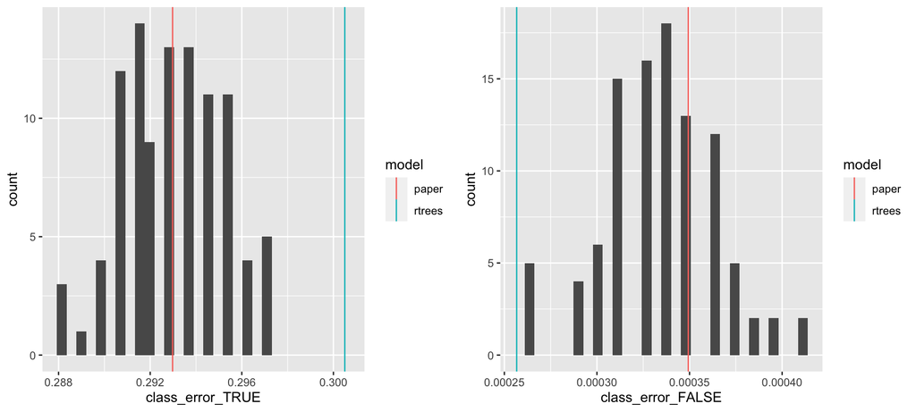

```r
hist_true <-
  res_confus %>%
  ggplot(aes(x = class_error_TRUE)) +
  geom_histogram() +
  geom_vline(data = comparison_values,
             mapping = aes(xintercept = class_error_true, color = model))

hist_false <-
  res_confus %>%
  ggplot(aes(x = class_error_FALSE)) +
  geom_histogram() +
  geom_vline(data = comparison_values,
             mapping = aes(xintercept = class_error_false, color = model))

plot_grid(hist_true, hist_false)
```

Class error for TRUE versus class error for FALSE and again the rtrees observations falls outside the range of the newly trained random forest models:

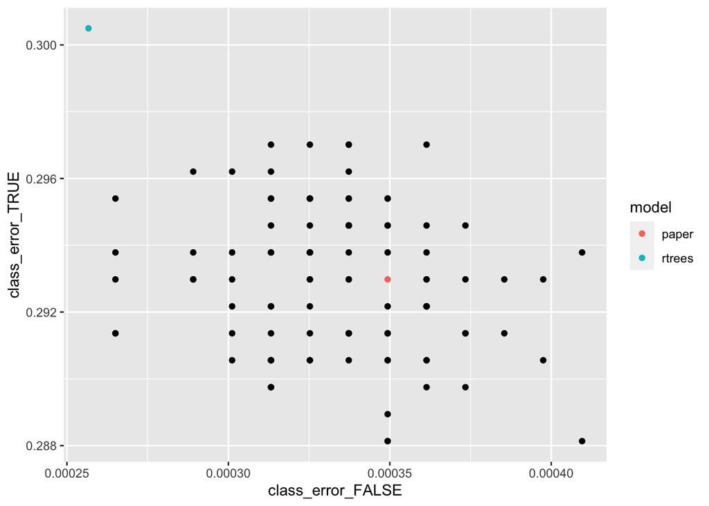

```r
ggplot() +
  geom_point(data = res_confus,
             mapping = aes(x = class_error_FALSE, y = class_error_TRUE)) +
  geom_point(
    data = comparison_values,
    mapping = aes(x = class_error_false, y = class_error_true, color = model)
  )
```

## Variable Importance

Prepare variable importance from `rtrees` and paper models for plotting:

```r
vi_ranks <-
  vi %>%
  arrange(desc(rtrees)) %>%
  mutate(rtrees_rank = 1:n()) %>%
  arrange(desc(paper)) %>%
  mutate(paper_rank = 1:n()) %>%
  select(-rtrees, -paper) %>%
  pivot_longer(names_to = "rf_model_id", values_to = "rank", cols = -features)
```

Tile plot showing the variable importance ranks for each model showing variability across newly trained models and some agreement (ex: rough_cor and ccf) and some disagreement (ex: sum_peaks and non_cms) with `rtrees`:

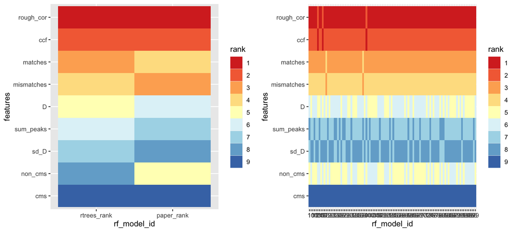

```r
rtrees_var_order <-
  vi_ranks %>%
  filter(rf_model_id == "rtrees_rank") %>%
  arrange(desc(rank)) %>%
  pull(features)

tile_org <-
  vi_ranks %>%
  mutate(
    rank = factor(rank, levels = 1:9),
    features = factor(features, levels = rtrees_var_order),
    rf_model_id = factor(rf_model_id, levels = c("rtrees_rank", "paper_rank"))
  ) %>%
  ggplot(aes(x = rf_model_id, y = features, fill = rank)) +
  geom_tile() +
  scale_fill_brewer(palette = "RdYlBu")

tile_new <-
  res_importance %>%
  mutate(
    rank = factor(rank, levels = 1:9),
    features = factor(features, levels = rtrees_var_order)
  ) %>%
  ggplot(aes(x = rf_model_id, y = features, fill = rank)) +
  geom_tile() +
  scale_fill_brewer(palette = "RdYlBu")

plot_grid(tile_org, tile_new)
```

Box plot of ranks across the models with colored points added for the `rtrees` and paper model variable importance ranks (features ordered by `rtrees` variable importance):

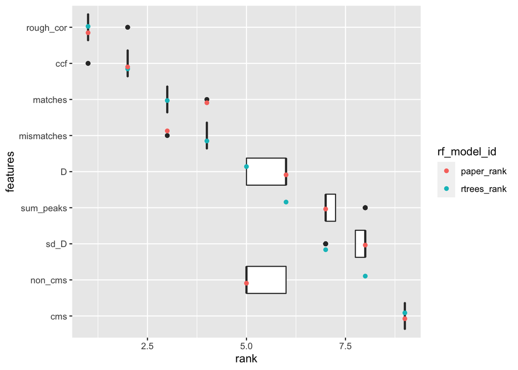

```r
res_importance %>%
  mutate(features = factor(features, levels = rtrees_var_order)) %>%
  ggplot() +
  geom_boxplot(aes(x = rank, y = features)) +
  geom_jitter(
    data = vi_ranks,
    mapping = aes(x = rank, y = features, color = rf_model_id),
    width = 0,
    height = 0.2
  )
```

Features versus variable importance ranks for new models (black lines and points) and `rtrees` and paper model (features ordered by `rtrees` variable importance):

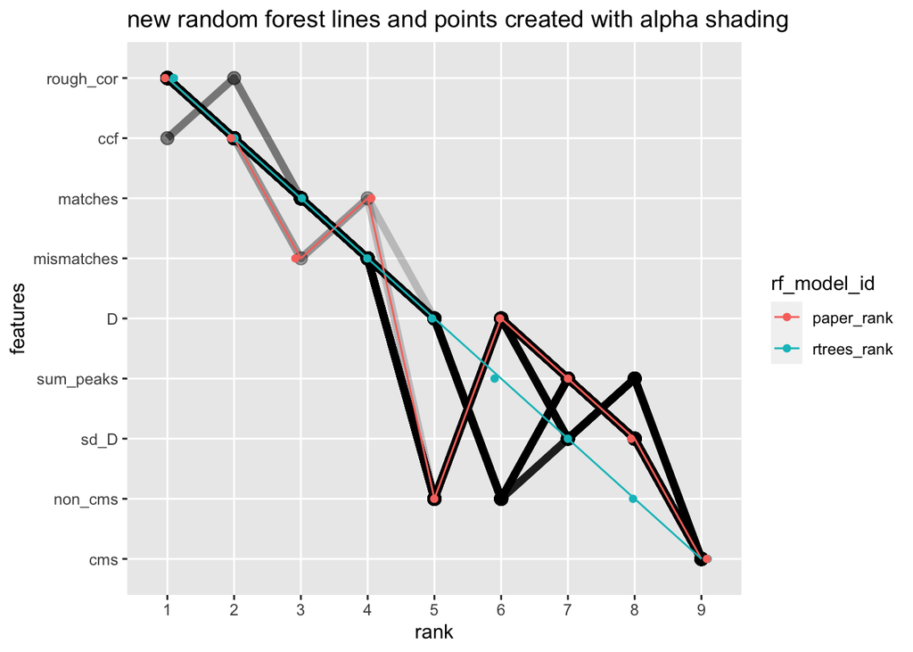

```r
res_importance %>%
  mutate(
    rank = factor(rank, levels = 1:9),
    features = factor(features, levels = rtrees_var_order)
  ) %>%
  ggplot(aes(x = rank, y = features, group = rf_model_id)) +
  geom_line(alpha = 0.2, size = 2) +
  geom_point(alpha = 0.2, size = 3) +
  geom_line(
    data = vi_ranks,
    mapping = aes(
      x = rank,
      y = features,
      group = rf_model_id,
      color = rf_model_id
    )
  ) +
  geom_jitter(
    data = vi_ranks,
    mapping = aes(x = rank, y = features, color = rf_model_id),
    width = 0.1,
    height = 0
  ) +
  labs(title = "new random forest lines and points created with alpha shading")
```